# Simple Website

David Loveday

3/20/2021

# The Simple Yet Awesome Website

## Welcome: About Me

### Who

```r
print("I am who I am and that's all I am")
```

```
## [1] "I am who I am and that's all I am"
```

### Where

```r
print("I am from France")
```

```
## [1] "I am from France"
```

### Interests

```r
print("I love building github websites")
```

```
## [1] "I love building github websites"
```

### Work

```r
print("I work in the coal mines")
```

```
## [1] "I work in the coal mines"
```

### Education

```r
print("I was educated at the school of hard knocks")
```

```
## [1] "I was educated at the school of hard knocks"
```

## The other tabs represent work/analyses that I have completed. Please check them out!

### Case Study #1 - Craft Beer

## Project Description & Deliverables

Brewtastic Analytics Inc was engaged by Anheuser-Busch InBev (Budweiser - NYSE: BUD) to study and provide a catalog of relevant statistics & further insights concerning general brewery and craft beer style trends across the United States.

The client requested these specific questions below to be addressed, along with any other material trends identified by Brewtastic: 1) How many breweries are present in each state? 2) What are the median ABV (Alcohol By Volume) and IBU (international Bitterness Units) for each state? 3) Which state has the maximum ABV? Which state has the most bitter beer? 4) Is there any apparent relationship between bitterness and alcoholic content?

## Data Sources & Quality Control

1. The US craft beer (‘Beers.csv’) and US breweries (‘Breweries.csv’) datasets were provided by the client.
2. Data for 2020 annual total consumption of beer per state and per capita by state were sourced from World Population Review which can be found at https://worldpopulationreview.com/state-rankings/alcohol-consumption-by-state

Data Quality Control: Beers.csv - Total rows: 2410 ABV: 62 nulls IBU: 1005 nulls (52 entries not included in the analysis) Missing values were populated with median or mean values from it’s given beer style population.  
There were 52 entries with no IBU information/statistics for their specific style and were not included in the analysis.

## Executive Summary of Conclusions

Brewtastic was able to successfully address each of the clients specific questions along with some fresh insights which may yield new business opportunities for the client. Brewtastic has developed a classification algorithm which can predict the style of an “Ale” beer when given information on the ABV and IBU.

3a) Which state has the maximum ABV? Colorado breweries appear to produce a label (Lee Hill Series Vol. 5 - Belgian Style Quadrupel Ale, Upslope Brewing Company - Boulder, CO) with the maximum ABV amoung all 50 states.

Additionally, Brewtastic has identified a potential business development opportunity for the client which should be explored further. Based on the observed per capita consumption trends, the states of New York, Ohio, Illinois and Florida appear to be underserved by local in-state brewers as compared to there densely-populated peers.

## Initialize libraries

```r
library(ggplot2)
library(tidyverse)
library(dplyr)
library(tidyr)
library(maps)
library(ggthemes)
library(plotly)
library(reshape)
library(githubinstall)
library(envirofacts)
library(eia)
library(stringr)
library(mapproj)
library(countrycode)
library(WDI)
library(stringr)
library(jsonlite)
library(plyr)
library(Rmisc)
library(class)
library(caret)
library(e1071)
library(scales)
library(RCurl) #getURL
library(rvest) #html_table, html_node
library(maps)
library(fiftystater)
library(mapproj)
```

## Import given datasets & merge together to create ‘Master’ database

```r
beer.file.path <- "C:\\Users\\dloveday\\Dropbox\\Family\\School\\SMU\\Courses\\Spring 2021\\DS 6306 - Doing Data Science\\Lecture Notes\\Unit 8 and 9 Case Study 1\\Beers.csv"
brewery.file.path <- "C:\\Users\\dloveday\\Dropbox\\Family\\School\\SMU\\Courses\\Spring 2021\\DS 6306 - Doing Data Science\\Lecture Notes\\Unit 8 and 9 Case Study 1\\Breweries.csv"
beer.per.capita.file.path <- "C:\\Users\\dloveday\\Dropbox\\Family\\School\\SMU\\Courses\\Spring 2021\\DS 6306 - Doing Data Science\\Lecture Notes\\Unit 8 and 9 Case Study 1\\Supplementary\\Beer - Gal per Capita 2021.csv"  # SOURCE: https://worldpopulationreview.com/state-rankings/alcohol-consumption-by-state
beer.total.consumption.file.path <- "C:\\Users\\dloveday\\Dropbox\\Family\\School\\SMU\\Courses\\Spring 2021\\DS 6306 - Doing Data Science\\Lecture Notes\\Unit 8 and 9 Case Study 1\\Supplementary\\Beer - Total Gal per State.csv"
#
beer.dB <- read.csv(beer.file.path)
brewery.dB <- read.csv(brewery.file.path)
beer.per.capita <- read.csv(beer.per.capita.file.path)
beer.total.consumption <- read.csv(beer.total.consumption.file.path)
#
master.beer.dB <- merge( x = beer.dB, y = brewery.dB, by.x = c("Brewery_id"), by.y = c("Brew_ID") )
#
```

## Cleanse & consolidate ‘Master’ database including Conversion of state full names to abbreviations

```r
master.beer.dB$Label <- master.beer.dB$Name.x
master.beer.dB$Brewer <- master.beer.dB$Name.y
master.beer.dB <- master.beer.dB[ , !names(master.beer.dB) %in% c("Name.x", "Name.y")]
master.beer.dB$State.Long <- state.name[match(master.beer.dB$State, state.abb)]
master.beer.dB$State.Long.Lower <- tolower(master.beer.dB$State.Long)

beer.per.capita$State <- state.abb[match(beer.per.capita$ï..State, state.name)]
beer.per.capita$Per.capita.gal <- beer.per.capita$alcoholConsumptionGallons
beer.per.capita$Per.capita.mm.gal <- beer.per.capita$Per.capita.gal / 1000000
beer.per.capita <- beer.per.capita %>% arrange(desc(beer.per.capita$Per.capita.gal))
beer.per.capita$Per.capita.rank <- seq(1, nrow(beer.per.capita), by = 1)
beer.per.capita <- beer.per.capita[, !names(beer.per.capita) %in% c("alcoholConsumptionGallons", "ï..State")]


beer.total.consumption$State.Long <- beer.total.consumption$State
beer.total.consumption$State <- state.abb[match(beer.total.consumption$State.Long, state.name)]
beer.total.consumption$Gross.mm.gal <- beer.total.consumption$Gallons.Overall..Millions.
beer.total.consumption$Gross.gal <- beer.total.consumption$Gross.mm.gal * 1000000
beer.total.consumption$Gross.rank <- beer.total.consumption$Rank
beer.total.consumption <- beer.total.consumption[, !names(beer.total.consumption) %in% c("Gallons.Overall..Millions.", "Rank")]

master.state.dB <- merge(beer.total.consumption, beer.per.capita, by = "State")
master.state.dB$Population <- master.state.dB$Gross.gal / master.state.dB$Per.capita.gal
master.state.dB$State.Long.Lower <- tolower(master.state.dB$State.Long)
```

## Create database of all beer styles/flavors from all makers and calculate stats (mean & median values for ABV, IBU..)

```r
master.beer.style.dB <- data.frame(Style = unique(master.beer.dB$Style))
for (i in 1:nrow(master.beer.style.dB)) {
  master.beer.style.dB.temp <- filter(master.beer.dB, master.beer.dB$Style == master.beer.style.dB$Style[i])
  master.beer.style.dB$Count[i] <- nrow(master.beer.style.dB.temp)
  master.beer.style.dB$Percent.Count[i] <- round(master.beer.style.dB$Count[i] / nrow(master.beer.dB) * 100,0)
  master.beer.style.dB$ABV.median[i] <- median(master.beer.style.dB.temp$ABV, na.rm = TRUE)
  master.beer.style.dB$ABV.mean[i] <- mean(master.beer.style.dB.temp$ABV, na.rm = TRUE)
  master.beer.style.dB$ABV.sd[i] <- sd(master.beer.style.dB.temp$ABV, na.rm = TRUE)
  master.beer.style.dB$IBU.median[i] <- median(master.beer.style.dB.temp$IBU, na.rm = TRUE)
  master.beer.style.dB$IBU.mean[i] <- mean(master.beer.style.dB.temp$IBU, na.rm = TRUE)
  master.beer.style.dB$IBU.sd[i] <- sd(master.beer.style.dB.temp$IBU, na.rm = TRUE)
}
```

## Fill in missing ABV & IBU values from dataset supplied by client with median/mean values from the beer style database

## Remove remaining NULL’s

## Final ‘Master’ database will be ready for analysis after this chunk

```r
for (i in 1:nrow(master.beer.dB)) {
  if (is.na(master.beer.dB$ABV[i])) {master.beer.dB$ABV[i] <- master.beer.style.dB$ABV.median[master.beer.style.dB$Style == master.beer.dB$Style[i]]  }
  if (is.na(master.beer.dB$ABV[i])) {master.beer.dB$ABV[i] <- master.beer.style.dB$ABV.mean[master.beer.style.dB$Style == master.beer.dB$Style[i]]  }

  if (is.na(master.beer.dB$IBU[i])) {master.beer.dB$IBU[i] <- master.beer.style.dB$IBU.median[master.beer.style.dB$Style == master.beer.dB$Style[i]]  }
  if (is.na(master.beer.dB$IBU[i])) {master.beer.dB$IBU[i] <- master.beer.style.dB$IBU.mean[master.beer.style.dB$Style == master.beer.dB$Style[i]]  }
}
master.beer.dB <- filter(master.beer.dB, !is.na(master.beer.dB$IBU))
```

## (1) EDA - Calculate Consumption & Brewery metrics for each state

```r
state.vector <- unique(master.state.dB$State)
for (i  in 1:length(state.vector)) {
  master.state.dB$Gross.brewery[ master.state.dB$State == state.vector[i] ] <- sum(str_count(brewery.dB$State, state.vector[i]))
  #
  master.state.dB.temp <- filter(master.beer.dB, master.beer.dB$State == state.vector[i])
  master.state.dB$ABV.median[ master.state.dB$State == state.vector[i] ] <- median(master.state.dB.temp$ABV, na.rm = TRUE)
  master.state.dB$IBU.median[ master.state.dB$State == state.vector[i] ] <- median(master.state.dB.temp$IBU, na.rm = TRUE)
  master.state.dB$ABV.max[ master.state.dB$State == state.vector[i] ] <- max(master.state.dB.temp$ABV, na.rm = TRUE)
  master.state.dB$IBU.max[ master.state.dB$State == state.vector[i] ] <- max(master.state.dB.temp$IBU, na.rm = TRUE)
}
master.state.dB$Per.capita.brewery <- master.state.dB$Gross.brewery / master.state.dB$Population
```

## (2) EDA - Setup Plotting Parameters

```r
map.data.state <- merge(map_data("state"),master.state.dB, by.x = "region", by.y = "State.Long.Lower")
map.data.state <- map.data.state[order(map.data.state$order), ]
```

## (3) EDA - Plots

```r
#
### 1.A US Heatmap of Gross Consumption
#
dev.new()
master.state.dB %>% ggplot( aes(map_id = State.Long.Lower) )+
  theme_bw()+
  theme(legend.title = element_text(size=7))+
  theme(legend.text = element_text(size=5))+
  geom_map(aes(fill = Gross.mm.gal), map = fifty_states, colour = "black" )+
  expand_limits(x = fifty_states$long, y = fifty_states$lat)+
  scale_fill_viridis_c(option = "magma", name = "Total Annual Gallons (MM)") +
  ggtitle("3.1 - Total 2020 Consumed Volume by State Heatmap")+
  coord_map()

dev.new()
master.state.dB %>% ggplot(aes(x = Population/10000000, y = Gross.mm.gal))+
  theme_bw()+
  geom_point()+
  ylab("Total Gallons (MM) Consumed")+
  xlab("Population (millions of residents)")+
  ggtitle("3.2 - Gross Consumption vs State Population")

plot.data <- master.state.dB[,c("State", "Gross.mm.gal")]
plot.data <- arrange(plot.data, desc(plot.data$Gross.mm.gal))
plot.data <- transform(plot.data, State = reorder(State, -Gross.mm.gal))

#dev.new()
plot.data %>%
  ggplot( aes(x = State, y = Gross.mm.gal) )+
  theme_bw()+
  theme(axis.title = element_text(size = 8))+
  theme(axis.text = element_text(size = 6))+
  geom_bar(stat = "identity" , position = "dodge")+
  ggtitle("3.3 - Total Consumption by State")+
  ylab("2020 Statewide Consumption (MM gal)")
#
### 1.B US Heatmap of Per Capita Consumption
#
#dev.new()
master.state.dB %>% ggplot( aes(map_id = State.Long.Lower) )+
  theme_bw()+
  theme(legend.title = element_text(size=7))+
  theme(legend.text = element_text(size=5))+
  geom_map(aes(fill = Per.capita.gal), map = fifty_states, colour = "black" )+
  expand_limits(x = fifty_states$long, y = fifty_states$lat)+
  scale_fill_viridis_c(option = "magma", name = "Annual Gallons per Capita") +
  ggtitle("3.4 - 2020 Consumed Volumes per Capita by State Heatmap")+
  coord_map()
#
### 1.C US Heatmap of Gross Brewery Count
#
#dev.new()
master.state.dB %>% ggplot( aes(map_id = State.Long.Lower) )+
  theme_bw()+
  theme(legend.title = element_text(size=7))+
  theme(legend.text = element_text(size=5))+
  geom_map(aes(fill = Gross.brewery), map = fifty_states, colour = "black" )+
  expand_limits(x = fifty_states$long, y = fifty_states$lat)+
  scale_fill_viridis_c(option = "magma", name = "Total Brewery Count") +
  ggtitle("3.5 - Total Brewery Count by State Heatmap")+
  coord_map()
#
### 1.D US Heatmap of Breweries per Capita (million)
#
#dev.new()
master.state.dB %>% ggplot( aes(map_id = State.Long.Lower) )+
  theme_bw()+
  theme(legend.title = element_text(size=7))+
  theme(legend.text = element_text(size=5))+
  geom_map(aes(fill = Per.capita.brewery*1000000), map = fifty_states, colour = "black" )+
  expand_limits(x = fifty_states$long, y = fifty_states$lat)+
  scale_fill_viridis_c(option = "magma", name = "Breweries per Capita (million residents)") +
  ggtitle("3.6 - Brewery Count per Capita by State Heatmap")+
  coord_map()
#
### 1.DD US Heatmap of median ABV
#
#dev.new()
master.state.dB %>% ggplot( aes(map_id = State.Long.Lower) )+
  theme_bw()+
  theme(legend.title = element_text(size=7))+
  theme(legend.text = element_text(size=5))+
  geom_map(aes(fill = ABV.median), map = fifty_states, colour = "black" )+
  expand_limits(x = fifty_states$long, y = fifty_states$lat)+
  scale_fill_viridis_c(option = "magma", name = "Median ABV for all Labels") +
  ggtitle("3.7 - Median ABV For All Labels Produced in State")+
  coord_map()
#

#
### 1.DDD US Heatmap of median IBU
#
#dev.new()
master.state.dB %>% ggplot( aes(map_id = State.Long.Lower) )+
  theme_bw()+
  theme(legend.title = element_text(size=7))+
  theme(legend.text = element_text(size=5))+
  geom_map(aes(fill = IBU.median), map = fifty_states, colour = "black" )+
  expand_limits(x = fifty_states$long, y = fifty_states$lat)+
  scale_fill_viridis_c(option = "magma", name = "Median IBU for all Labels") +
  ggtitle("3.8 - Median IBU For All Labels Produced in State")+
  coord_map()
#
### 1.E Histogram of Gross Breweries by State
#
plot.data <- master.state.dB[,c("State", "Gross.brewery")]
plot.data <- arrange(plot.data, desc(plot.data$Gross.brewery))
plot.data <- transform(plot.data, State = reorder(State, -Gross.brewery))
plot.data <- head(plot.data, 10)

#dev.new()
plot.data %>%
  ggplot( aes(x = State, y = Gross.brewery) )+
  theme_bw()+
  theme(axis.title = element_text(size = 8))+
  theme(axis.text = element_text(size = 6))+
  geom_bar(stat = "identity" , position = "dodge")+
  ggtitle("3.9 - Top 10: Total Brewery Count by State")+
  ylab("Statewide Count of Breweries")
#
### 1.F Histogram of Per Capita Breweries by State
#
plot.data <- master.state.dB[,c("State", "Per.capita.brewery")]
plot.data <- arrange(plot.data, desc(plot.data$Per.capita.brewery))
plot.data <- transform(plot.data, State = reorder(State, -Per.capita.brewery))
plot.data <- head(plot.data, 10)

#dev.new()
plot.data %>%
  ggplot( aes(x = State, y = Per.capita.brewery*1000000) )+
  theme_bw()+
  theme(axis.title = element_text(size = 8))+
  theme(axis.text = element_text(size = 6))+
  geom_bar(stat = "identity" , position = "dodge")+
  ylab("Breweries per Capita (million residents)")+
  ggtitle("3.10 - Top 10: Breweries per Capita by State")

#
### 1.G Top 10 Histogram of Per Capita Consumption by State
#
plot.data <- master.state.dB[,c("State", "Per.capita.gal")]
plot.data <- arrange(plot.data, desc(plot.data$Per.capita.gal))
plot.data <- transform(plot.data, State = reorder(State, -Per.capita.gal))
plot.data <- head(plot.data, 10)

#dev.new()
plot.data %>%
  ggplot( aes(x = State, y = Per.capita.gal) )+
  theme_bw()+
  theme(axis.title = element_text(size = 8))+
  theme(axis.text = element_text(size = 6))+
  geom_bar(stat = "identity" , position = "dodge")+
  ylab("2020 Consumption Per Capita by State")+
  ggtitle("3.11 - Top 10: Consumption per Capita by State")
#
#
### 1.G2 Histogram of Per Capita Consumption by State
#
plot.data <- master.state.dB[,c("State", "Per.capita.gal")]
plot.data <- arrange(plot.data, desc(plot.data$Per.capita.gal))
plot.data <- transform(plot.data, State = reorder(State, -Per.capita.gal))

#dev.new()
plot.data %>%
  ggplot( aes(x = State, y = Per.capita.gal) )+
  theme_bw()+
  theme(axis.title = element_text(size = 8))+
  theme(axis.text = element_text(size = 6))+
  geom_bar(stat = "identity" , position = "dodge")+
  ylab("2020 Consumption Per Capita by State")+
  ggtitle("3.12 - Consumption per Capita by State")
```

[output not shown]

## (4) EDA - IBU & Alcohol By Volume Analysis by State

4. PLOT INDEX Plot 4.1 - Median ABV by State Plot 4.2 - Max ABV by State Plot 4.3 - Top 10: Max ABV by State Plot 4.4 - Max ABV For All Labels Produced in State Plot 4.5 - Top 10: Median ABV by State Plot 4.6 - Plot 4.7 - Top 10: Median IBU by State Plot 4.8 - Max IBU by State Plot 4.9 - Top 10: Max IBU by State Plot 4.10 - Max IBU For All Labels Produced in State

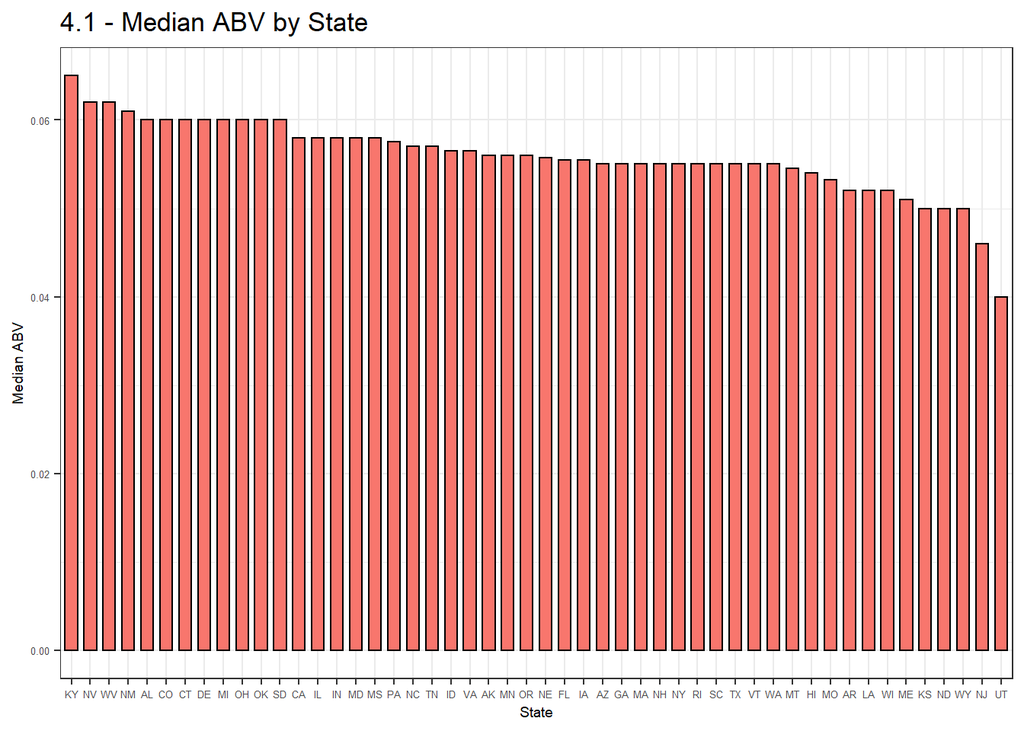

```r
#
############### (4) IBU & Alcohol Content Analysis by State (Histograms)
#
#### Median ABV by State
plot.data <- master.state.dB[,c("State", "ABV.median")]
plot.data <- transform(plot.data, State = reorder(State, -ABV.median))

#dev.new()
plot.data %>% melt(id.vars = c("State")) %>%
  ggplot( aes(x = State, y = value, fill = variable) )+
  theme_bw()+
  theme(axis.title = element_text(size = 7))+
  theme(axis.text = element_text(size = 5))+
  geom_bar(stat = "identity" , position = "dodge", color = "black", show.legend = FALSE, width = 0.65)+
  ylab("Median ABV")+
  ggtitle("4.1 - Median ABV by State")
```

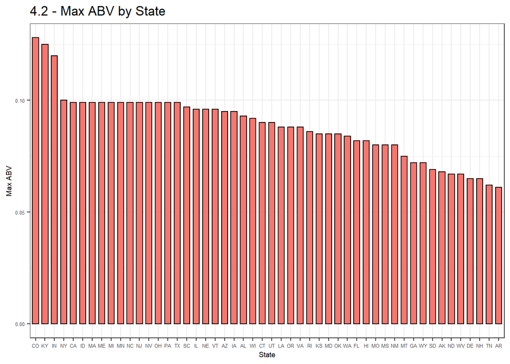

```r
#
#
#### Max ABV by State Historgram
plot.data <- master.state.dB[,c("State", "ABV.max")]
plot.data <- transform(plot.data, State = reorder(State, -ABV.max))

#dev.new()
plot.data %>% melt(id.vars = c("State")) %>%
  ggplot( aes(x = State, y = value, fill = variable) )+
  theme_bw()+
  theme(axis.title = element_text(size = 7))+
  theme(axis.text = element_text(size = 5))+
  geom_bar(stat = "identity" , position = "dodge", color = "black", show.legend = FALSE, width = 0.65)+
  ylab("Max ABV")+
  ggtitle("4.2 - Max ABV by State")
```

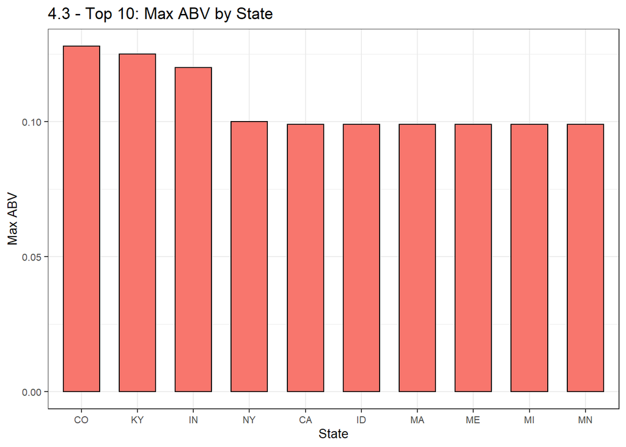

```r
#

#
#### Top 10: Max ABV by State Historgram
plot.data <- master.state.dB[,c("State", "ABV.max")]
plot.data <- arrange(plot.data, desc(plot.data$ABV.max))
plot.data <- transform(plot.data, State = reorder(State, -ABV.max))
plot.data <- head(plot.data, 10)

#dev.new()
plot.data %>% melt(id.vars = c("State")) %>%
  ggplot( aes(x = State, y = value, fill = variable) )+
  theme_bw()+
  theme(axis.title = element_text(size = 10))+
  theme(axis.text = element_text(size = 8))+
  geom_bar(stat = "identity" , position = "dodge", color = "black", show.legend = FALSE, width = 0.65)+
  ylab("Max ABV")+
  ggtitle("4.3 - Top 10: Max ABV by State")
```

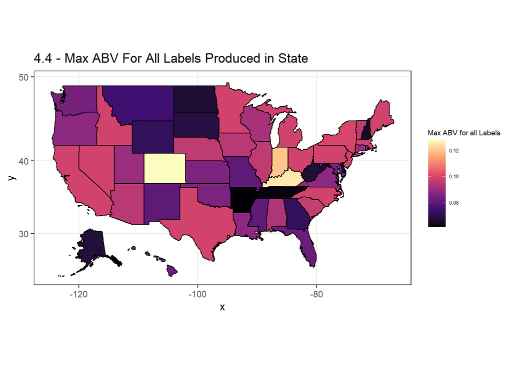

```r
#
### US Heatmap of max ABV
#
#dev.new()
master.state.dB %>% ggplot( aes(map_id = State.Long.Lower) )+
  theme_bw()+
  theme(legend.title = element_text(size=7))+
  theme(legend.text = element_text(size=5))+
  geom_map(aes(fill = ABV.max), map = fifty_states, colour = "black" )+
  expand_limits(x = fifty_states$long, y = fifty_states$lat)+
  scale_fill_viridis_c(option = "magma", name = "Max ABV for all Labels") +
  ggtitle("4.4 - Max ABV For All Labels Produced in State")+
  coord_map()
```

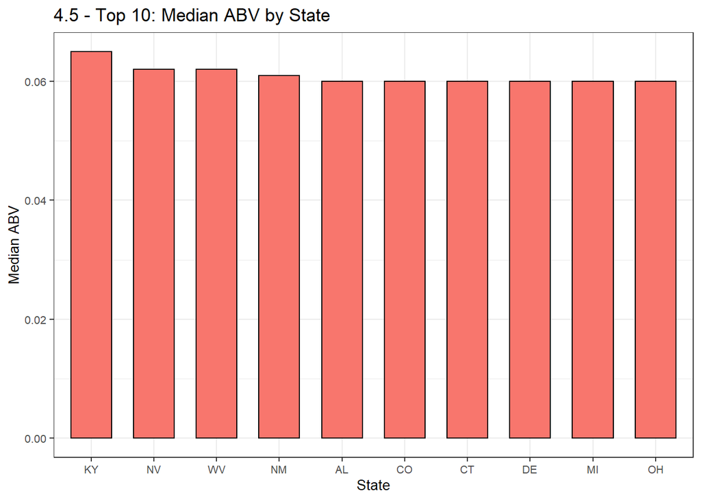

```r
#
#### Top 10: Median ABV by State
plot.data <- master.state.dB[,c("State", "ABV.median")]
plot.data <- arrange(plot.data, desc(plot.data$ABV.median))
plot.data <- transform(plot.data, State = reorder(State, -ABV.median))
plot.data <- head(plot.data, 10)

#dev.new()
plot.data %>% melt(id.vars = c("State")) %>%
  ggplot( aes(x = State, y = value, fill = variable) )+
  theme_bw()+
  theme(axis.title = element_text(size = 10))+
  theme(axis.text = element_text(size = 8))+
  geom_bar(stat = "identity" , position = "dodge", color = "black", show.legend = FALSE, width = 0.65)+
  ylab("Median ABV")+
  ggtitle("4.5 - Top 10: Median ABV by State")
```

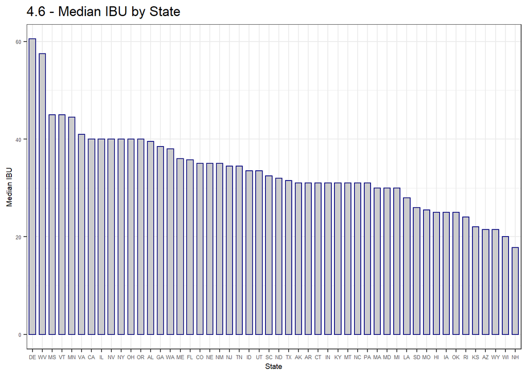

```r
#
#### Median IBU by State
plot.data <- master.state.dB[,c("State", "IBU.median")]
plot.data <- transform(plot.data, State = reorder(State, -IBU.median))

#dev.new()
plot.data %>% melt(id.vars = c("State")) %>%
  ggplot( aes(x = State, y = value) )+
  theme_bw()+
  theme(axis.title = element_text(size = 7))+
  theme(axis.text = element_text(size = 5))+
  geom_bar(stat = "identity" , position = "dodge", fill = "grey80", color = "navy", show.legend = FALSE, width = 0.65)+
  ylab("Median IBU")+
  ggtitle("4.6 - Median IBU by State")
```

[figure not shown]

```r
#### Top 10: Median IBU by State
plot.data <- master.state.dB[,c("State", "IBU.median")]
plot.data <- arrange(plot.data, plot.data$IBU.median)
plot.data <- transform(plot.data, State = reorder(State, -IBU.median))
plot.data <- head(plot.data,10)

#dev.new()
plot.data %>% melt(id.vars = c("State")) %>%
  ggplot( aes(x = State, y = value) )+
  theme_bw()+
  theme(axis.title = element_text(size = 10))+
  theme(axis.text = element_text(size = 8))+
  geom_bar(stat = "identity" , position = "dodge", fill = "grey80", color = "navy", show.legend = FALSE, width = 0.65)+
  ylab("Median IBU")+
  ggtitle("4.7 - Top 10: Median IBU by State")
```

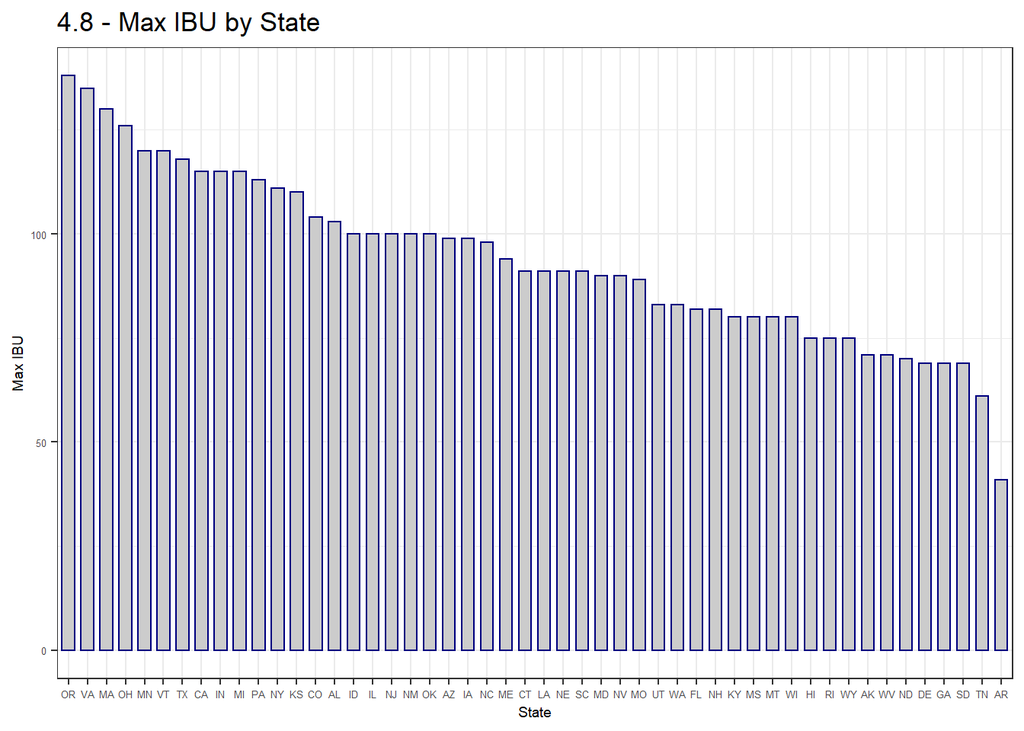

```r
#### Max IBU by State Historgram
plot.data <- master.state.dB[,c("State", "IBU.max")]
plot.data <- arrange(plot.data, desc(plot.data$IBU.max))
plot.data <- transform(plot.data, State = reorder(State, -IBU.max))

#dev.new()
plot.data %>% melt(id.vars = c("State")) %>%
  ggplot( aes(x = State, y = value) )+
  theme_bw()+
  theme(axis.title = element_text(size = 7))+
  theme(axis.text = element_text(size = 5))+
  geom_bar(stat = "identity" , position = "dodge", fill = "grey80", color = "navy", show.legend = FALSE, width = 0.65)+
  ylab("Max IBU")+
  ggtitle("4.8 - Max IBU by State")
```

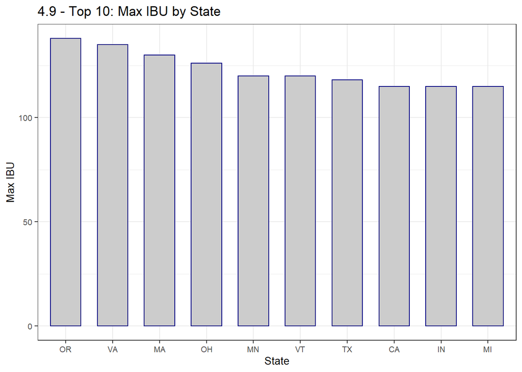

```r
#### Top 10: Max IBU by State Historgram
plot.data <- master.state.dB[,c("State", "IBU.max")]
plot.data <- arrange(plot.data, desc(plot.data$IBU.max))
plot.data <- transform(plot.data, State = reorder(State, -IBU.max))
plot.data <- head(plot.data, 10)

#dev.new()
plot.data %>% melt(id.vars = c("State")) %>%
  ggplot( aes(x = State, y = value) )+
  theme_bw()+
  theme(axis.title = element_text(size = 10))+
  theme(axis.text = element_text(size = 8))+
  geom_bar(stat = "identity" , position = "dodge", fill = "grey80", color = "navy", show.legend = FALSE, width = 0.65)+
  ylab("Max IBU")+
  ggtitle("4.9 - Top 10: Max IBU by State")
```

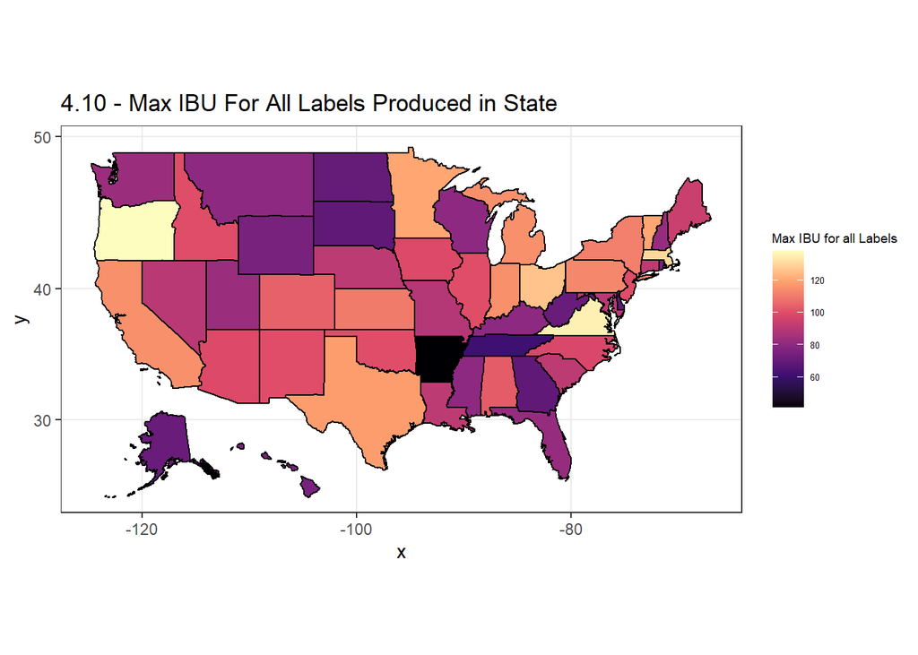

```r
#
### US Heatmap of max IBU
#
#dev.new()
master.state.dB %>% ggplot( aes(map_id = State.Long.Lower) )+
  theme_bw()+
  theme(legend.title = element_text(size=7))+
  theme(legend.text = element_text(size=5))+
  geom_map(aes(fill = IBU.max), map = fifty_states, colour = "black" )+
  expand_limits(x = fifty_states$long, y = fifty_states$lat)+
  scale_fill_viridis_c(option = "magma", name = "Max IBU for all Labels") +
  ggtitle("4.10 - Max IBU For All Labels Produced in State")+
  coord_map()
```

```r
#
```

## (5) EDA - Relationship between IBU & ABV

PLOT INDEX: 5.1 - All Label Data Colored by Beer Style - ABV vs IBU; 5.2 - Best-Fit Linear Regressions by Beer Style (Includes Artifical NULL Fills) - ABV vs IBU; 5.3 - Best-Fit Linear Regressions by Beer Style (Not Including Artifical NULL Fills) - ABV vs IBU

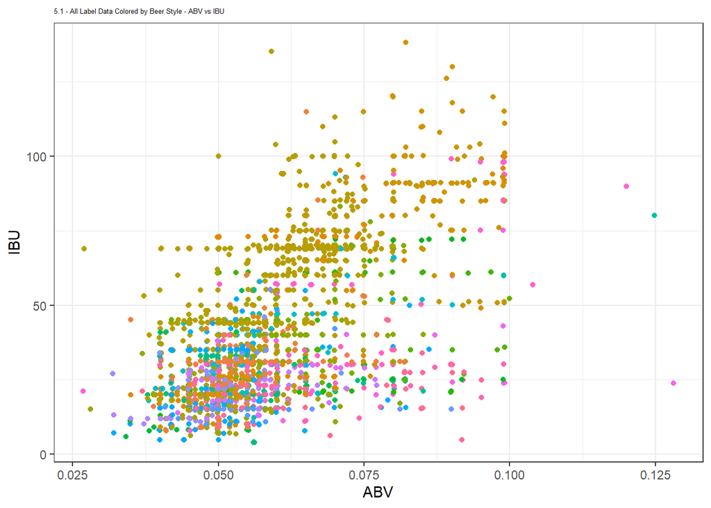

```r
#
#### ABV vs IBU Relationships - All Styles, All Labels Scatter
#dev.new()
master.beer.dB %>% ggplot(aes( x = ABV, y = IBU, color = Style))+
  theme_bw()+
  theme(plot.title = element_text(size=5))+
  geom_point(position = "jitter" , show.legend = FALSE)+
  ggtitle("5.1 - All Label Data Colored by Beer Style - ABV vs IBU")
```

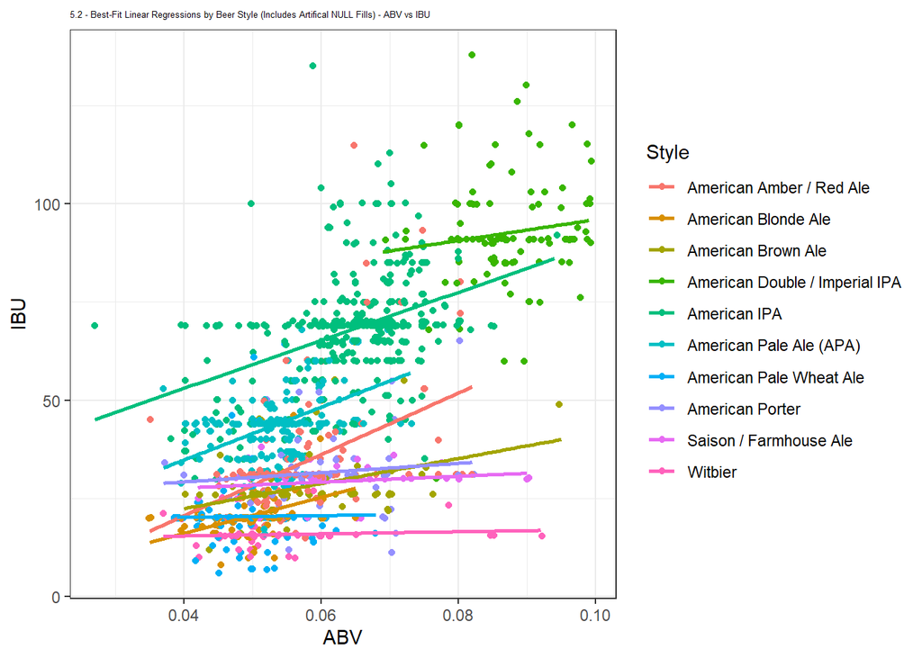

```r
#
#### ABV vs IBU Relationships - Top 10 Styles, All Labels Scatter
plot.data.ref <- arrange(master.beer.style.dB, desc(master.beer.style.dB$Count))[1:10,c("Style", "ABV.median", "ABV.mean", "ABV.sd")]
plot.data <- master.beer.dB[master.beer.dB$Style %in% plot.data.ref$Style, c("Style", "ABV", "IBU")]

#dev.new()
plot.data %>% ggplot(aes(x = ABV, y = IBU, color = Style))+
  theme_bw()+
  theme(plot.title = element_text(size=5))+
  geom_point(position = "jitter")+
  geom_smooth(method = 'lm', se = FALSE)+
  ggtitle("5.2 - Best-Fit Linear Regressions by Beer Style (Includes Artifical NULL Fills) - ABV vs IBU")
```

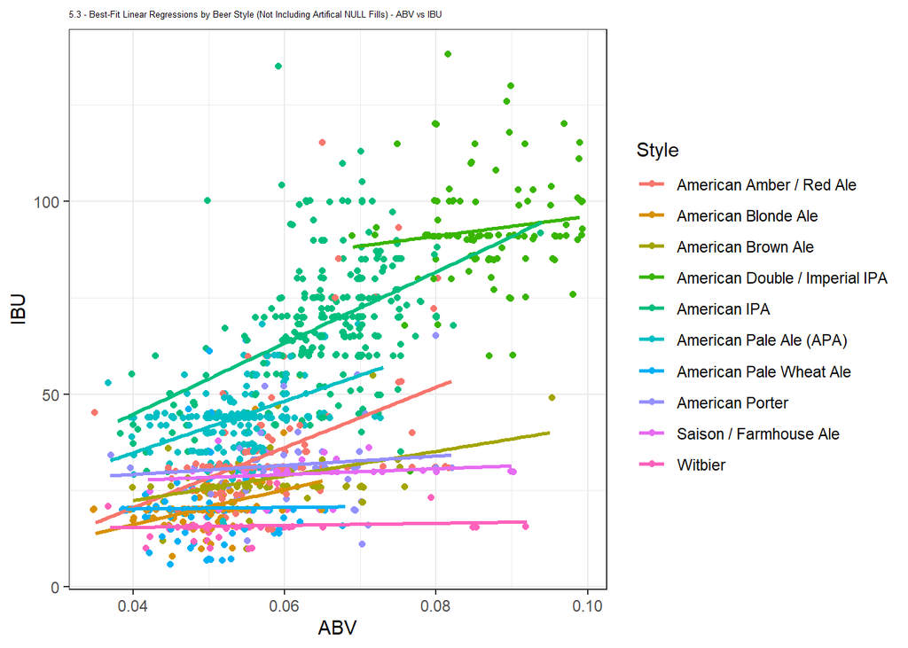

```r
#
#### ABV vs IBU Relationships - Top 10 Styles, All Labels minus IBU = 69 - Scatter
plot.data.ref <- arrange(master.beer.style.dB, desc(master.beer.style.dB$Count))[1:10,c("Style", "ABV.median", "ABV.mean", "ABV.sd")]
plot.data <- master.beer.dB[master.beer.dB$Style %in% plot.data.ref$Style, c("Style", "ABV", "IBU")] %>% filter(IBU != 69)

#dev.new()
plot.data %>% ggplot(aes(x = ABV, y = IBU, color = Style))+
  theme_bw()+
  theme(plot.title = element_text(size=5))+
  geom_point(position = "jitter")+
  geom_smooth(method = 'lm', se = FALSE, linestyle = "dashed")+
  ggtitle("5.3 - Best-Fit Linear Regressions by Beer Style (Not Including Artifical NULL Fills) - ABV vs IBU")
```

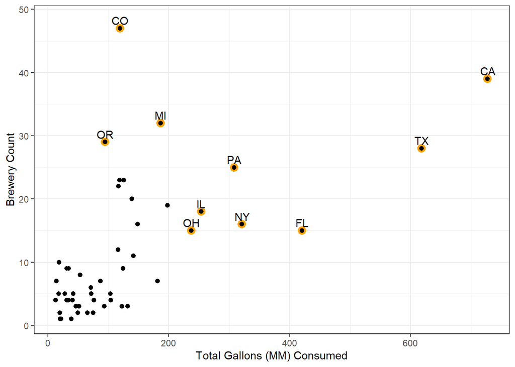

```r
#
#### Breweries per Total Gallons Consumed by State
master.state.dB$Breweries.per.mm.gal.total <- master.state.dB$Gross.brewery / master.state.dB$Gross.mm.gal

#dev.new()
ggplot()+
  theme_bw()+
  geom_point( data = filter(master.state.dB, master.state.dB$Gross.brewery >= 28 | master.state.dB$Gross.mm.gal >= 200), aes(y = Gross.brewery, x = Gross.mm.gal), color = "orange", size = 3.5)+
  geom_point( data = master.state.dB,aes(y = Gross.brewery, x = Gross.mm.gal), size = 1.75)+
  geom_text( data = filter(master.state.dB, master.state.dB$Gross.brewery >= 28 | master.state.dB$Gross.mm.gal >= 200),
              aes(y = Gross.brewery, x = Gross.mm.gal, label = State),
              nudge_x = 0.2,
              nudge_y = 1.25)+
  ylab("Brewery Count")+
  xlab("Total Gallons (MM) Consumed")
```

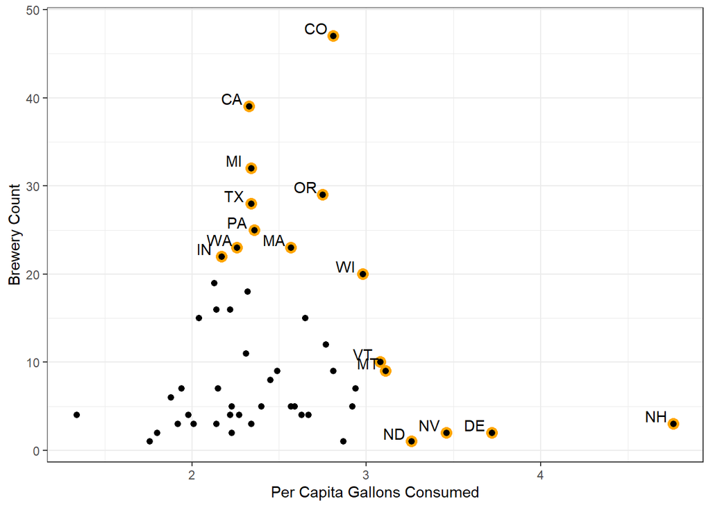

```r
#
#### Breweries per Capita Gallons Consumed by State
master.state.dB$Breweries.per.gal.capita <- master.state.dB$Gross.brewery / master.state.dB$Per.capita.gal

#dev.new()
ggplot()+
  theme_bw()+
  geom_point(data = filter(master.state.dB, master.state.dB$Gross.brewery >= 20 | master.state.dB$Per.capita.gal >= 3), aes(y = Gross.brewery, x = Per.capita.gal), color = "orange", size = 3.5)+
  geom_point(data = master.state.dB,aes(y = Gross.brewery, x = Per.capita.gal), size = 1.75)+
  geom_text( data = filter(master.state.dB, master.state.dB$Gross.brewery >= 20 | master.state.dB$Per.capita.gal >= 3),
             aes(y = Gross.brewery, x = Per.capita.gal, label = State),
             nudge_x = -0.1,
             nudge_y = 0.9)+
  ylab("Brewery Count")+
  xlab("Per Capita Gallons Consumed")
```

## k-NN Analysis which seeks to predict “Ale” (“IPA” or “Other”) type based upon supplied ABV & IBU pairs

6. Model constructed using 30/70 test-to-train split;
7. Optimal k, which maximizes Accuracy, Specificity, and Specificity is calculated by testing a range of possible k values from 1-300;
8. Synthetic grid built which simulates many different, evenly spaced ABV, IBU pairs;
9. Syntethic grid pairs are put through model and probabilities for each “Ale” type are captured;
10. Probability heatmaps, with interpolation, are constructed for each “Ale” type using the synthetic grid predictions

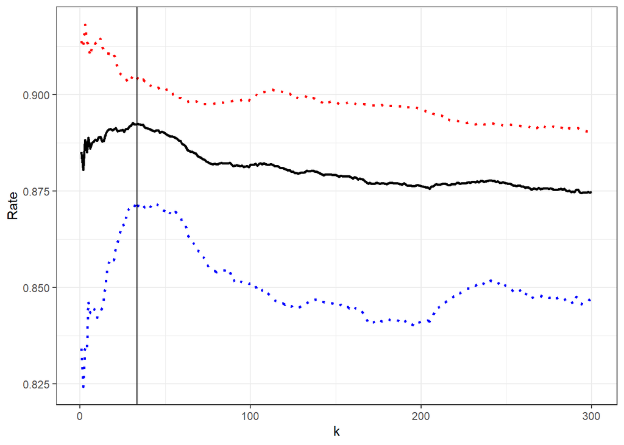

```r
#
#### Subset for IPA's & other Ale's (any beer with "Ale" but not IPA)
knn.data.all.Ale <- filter(master.beer.dB, grepl('India|IPA|Ale', Style) | grepl('India|IPA|Ale', Label))
knn.data.IPA     <- filter(knn.data.all.Ale, grepl('India|IPA', Style) | grepl('India|IPA', Label))
knn.data.other.Ale <- knn.data.all.Ale %>% anti_join(knn.data.IPA)

for (i in 1:nrow(knn.data.all.Ale)) {
  if (grepl('India|IPA', knn.data.all.Ale$Style[i]) |  grepl('India|IPA|Ale', knn.data.all.Ale$Label) ) { knn.data.all.Ale$Ale.Type[i] <- "IPA" }
  else { knn.data.all.Ale$Ale.Type[i] <- "Other" }
}

# Rescale axes for euclidean distance calculation
knn.data.all.Ale$ABV.scale <- scale(knn.data.all.Ale$ABV)
ABV.scale.mean <-  mean(knn.data.all.Ale$ABV)
ABV.scale.sd   <-  sd(knn.data.all.Ale$ABV)

knn.data.all.Ale$IBU.scale <- scale(knn.data.all.Ale$IBU)
IBU.scale.mean <- mean(knn.data.all.Ale$IBU)
IBU.scale.sd   <- sd(knn.data.all.Ale$IBU)

# Create synthetic grid of ABV & IBU points
ABV.synth.seq <- seq(min(knn.data.all.Ale$ABV), max(knn.data.all.Ale$ABV), (max(knn.data.all.Ale$ABV) - min(knn.data.all.Ale$ABV))/50)
IBU.synth.seq <- seq(min(knn.data.all.Ale$IBU), max(knn.data.all.Ale$IBU), (max(knn.data.all.Ale$IBU) - min(knn.data.all.Ale$IBU))/50)

ABV.IBU.synth.dB <- data.frame()
ABV.IBU.synth.dB <- expand.grid(ABV = ABV.synth.seq, IBU = IBU.synth.seq)
ABV.IBU.synth.dB$ABV.scale <- (ABV.IBU.synth.dB$ABV - ABV.scale.mean) / ABV.scale.sd
ABV.IBU.synth.dB$IBU.scale <- (ABV.IBU.synth.dB$IBU - IBU.scale.mean) / IBU.scale.sd

# Run k.nn for test/train at range of k's to identify sweet spot
knn.test.train.list <- list()

for (j in 1:50) {
  set.seed(j)
  splitPerc <- 0.70 #Use a 70/30 train to test ratio

  trainIndicies <- sample( 1:dim(knn.data.all.Ale)[1], round(splitPerc * dim(knn.data.all.Ale)[1]))
  train <- knn.data.all.Ale[trainIndicies, ]
  test <- knn.data.all.Ale[-trainIndicies, ]

  k.max <- 300
  knn.Ale.test.train <- data.frame(matrix(nrow = k.max, ncol = 4))
  colnames(knn.Ale.test.train) <- c("k", "Accuracy", "Sensitivity", "Specificity")

  for (i in 1:k.max) {
    classifications = knn(train[,c(14,15)],test[,c(14,15)],train$Ale.Type, prob = TRUE, k = i)
    confusion.matrix <- confusionMatrix(table(classifications,test$Ale.Type))

    knn.Ale.test.train$k[i] <- i
    knn.Ale.test.train$Accuracy[i] <-  confusion.matrix$overall[1]
    knn.Ale.test.train$Sensitivity[i] <- confusion.matrix$byClass[1]
    knn.Ale.test.train$Specificity[i] <- confusion.matrix$byClass[2]
  }
  knn.test.train.list[[j]] <- knn.Ale.test.train
}
#############################################################################################################################
# Calculate mean Accuracy/Sensitivity/Specificity for 50 random 30/70 test/train splits
knn.Ale.unlist <- do.call(rbind, knn.test.train.list)
knn.Ale.stats <- data.frame(matrix(nrow = k.max))
for (i in 1:k.max) {
  temp.data <- filter(knn.Ale.unlist, knn.Ale.unlist$k == i)

  knn.Ale.stats$k[i] <- i
  knn.Ale.stats$Accuracy.mean[i] <- mean(temp.data$Accuracy)
  knn.Ale.stats$Sensitivity.mean[i] <- mean(temp.data$Sensitivity)
  knn.Ale.stats$Specificity.mean[i] <- mean(temp.data$Specificity)
}

##dev.new()
knn.Ale.stats %>%
  ggplot(aes(x = k, y = Accuracy))+
  theme_bw()+
  geom_line(aes(x = k, y = Accuracy.mean), color = "black", size = 0.9)+
  geom_line(aes(x = k, y = Sensitivity.mean), color = "blue", linetype = "dotted", size = 0.9)+
  geom_line(aes(x = k, y = Specificity.mean), color = "red", linetype = "dotted", size = 0.9)+
  geom_vline(aes(xintercept = sqrt(nrow(train))))+
  ylab("Rate")
```

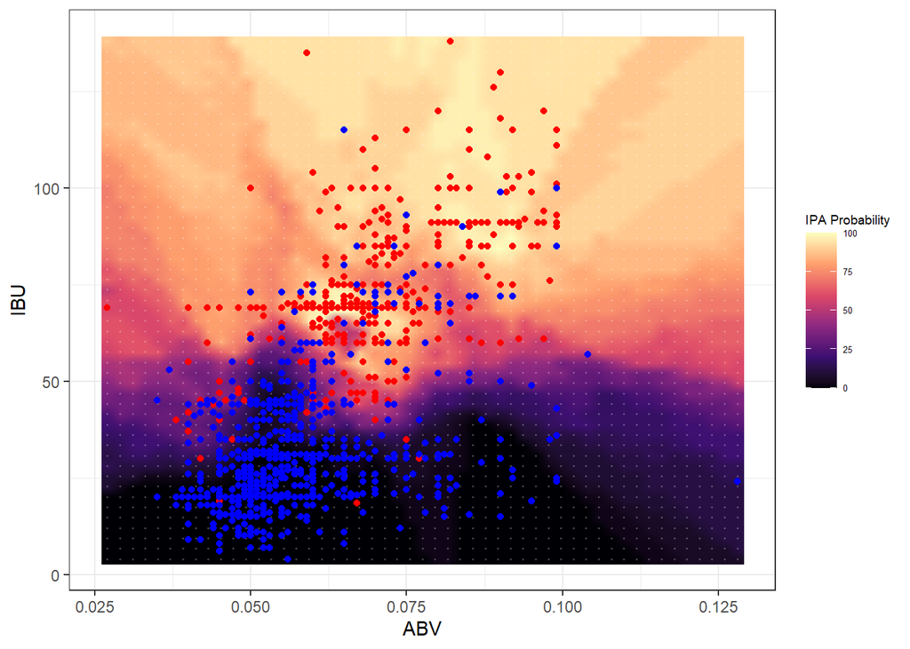

```r
#############################################################################################################################
# Run synthetic grid through k.NN model at k = 34

synth.class <- knn(knn.data.all.Ale[,c(14,15)], ABV.IBU.synth.dB[,c(3,4)], knn.data.all.Ale$Ale.Type, prob = TRUE, k = round(sqrt(nrow(train))))
ABV.IBU.synth.dB$prediction <- synth.class
ABV.IBU.synth.dB$probability <- attributes(synth.class)$prob

for (i in 1:nrow(ABV.IBU.synth.dB)) {
  if (ABV.IBU.synth.dB$prediction[i] == "IPA") { ABV.IBU.synth.dB$IPA.prob[i] <- ABV.IBU.synth.dB$probability[i]*100 }
  if (ABV.IBU.synth.dB$prediction[i] != "IPA") { ABV.IBU.synth.dB$IPA.prob[i] <- (1 - ABV.IBU.synth.dB$probability[i])*100 }
  ABV.IBU.synth.dB$Other.prob[i] <- 100 - ABV.IBU.synth.dB$IPA.prob[i]
}

### Build probability heatmap rasters for syntetic grid prediction classifications

# Probability heatmap of IPA
##dev.new()
ABV.IBU.synth.dB %>%
  ggplot()+
  theme_bw()+
  theme(legend.title = element_text(size=7))+
  theme(legend.text = element_text(size=5))+
  geom_raster(data = ABV.IBU.synth.dB, aes(x = ABV, y = IBU, fill = IPA.prob), interpolate = TRUE)+
  geom_point(data = ABV.IBU.synth.dB, aes(x = ABV, y = IBU), size = 0.25, color = "white", alpha = 0.2)+
  geom_point(data = knn.data.IPA, aes(x = ABV, y = IBU), color = "red")+
  geom_point(data = knn.data.other.Ale, aes(x = ABV, y = IBU), color = "blue")+
  scale_fill_viridis_c(option = "magma", name = "IPA Probability")
```

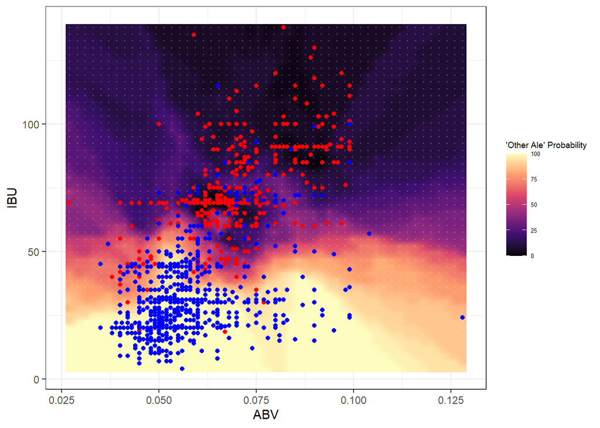

```r
# Probability heatmap of Other Ales
##dev.new()
ABV.IBU.synth.dB %>%
  ggplot()+
  theme_bw()+
  theme(legend.title = element_text(size=7))+
  theme(legend.text = element_text(size=5))+
  geom_raster(data = ABV.IBU.synth.dB, aes(x = ABV, y = IBU, fill = Other.prob), interpolate = TRUE)+
  geom_point(data = ABV.IBU.synth.dB, aes(x = ABV, y = IBU), size = 0.25, color = "white", alpha = 0.2)+
  geom_point(data = knn.data.IPA, aes(x = ABV, y = IBU), color = "red")+
  geom_point(data = knn.data.other.Ale, aes(x = ABV, y = IBU), color = "blue")+
  scale_fill_viridis_c(option = "magma", name = "'Other Ale' Probability")
```